# 5 Comparison of macroinverbrate biodiversity

Now that we’ve generated all this data we can use it to address our first research objective.

**Compare species richness and diversity for selected headwater streams across spring, summer, and fall.**

Keep in mind that we have data sets from two locations (Rand Brook and Schoolhouse Brook) for three different sampling seasons from multiple years.

- Summer: July 9th - Aug 6th
- Fall: October 3rd - 31st
- Spring April 11th - May 9th

You can download the data sets from our shared google folder.

## 5.1 Get set up

Before we can get started let’s load our packages.

```r
# read libraries
library(readr)
library(janitor)
library(lubridate)
library(tidyr)
library(dplyr)
library(glue)
library(ggplot2)
library(patchwork)
library(knitr)
```

Now, we can read in our data sets.

```r
rand_2210 <- read_delim("data/macros_RAND_2022-10-19.tsv", delim = "\t") %>%
  clean_names()

rand_2305 <- read_delim("data/macros_RAND_2023-05-30.tsv", delim = "\t") %>%
  clean_names()

rand_2307 <- read_delim("data/macros_RAND_2023-07-07.tsv", delim = "\t") %>%
  clean_names()

rand_2310 <- read_delim("data/macros_RAND_2023-10-18.tsv", delim = "\t") %>%
  clean_names()

rand_2407 <- read_delim("data/macros_RAND_2024-07-09.tsv", delim = "\t") %>%
  clean_names()

rand_2410 <- read_delim("data/macros_RAND_2024-10-02.tsv", delim = "\t") %>%
  clean_names()

schb_2210 <- read_delim("data/macros_SCHB_2022-11-02.tsv", delim = "\t") %>%
  clean_names()

schb_2305 <- read_delim("data/macros_SCHB_2023-05-30.tsv", delim = "\t") %>%
  clean_names()

schb_2410 <- read_delim("data/macros_SCHB_2024-10-23.tsv", delim = "\t") %>%
  clean_names()
```

First, we will want to look at the number of individuals in each taxonomic group and calculate their relative abundances and compare species richness and diversity across the two locations.

Let’s start with the data set from our visit to rand brook this semester.

We can figure out the richness by determining the number of individuals in each of the different orders and family.

```r
kable(
  rand_2410 %>%
    group_by( order) %>%
    count()
)
```

| order | n |
| --- | --- |
| Coleoptera | 18 |
| Diptera | 5 |
| Ephemeroptera | 5 |
| Hemiptera | 1 |
| Megaloptera | 4 |
| Odonata | 27 |
| Plecoptera | 11 |
| Trichoptera | 26 |

This is helpful but our sample sizes differ among locations so we will want to determine the relative abundance for each location.

We can do this by dividing the number of individuals in a certain group by the total number of individuals sampled at that location.

```r
kable(
  rand_2410 %>%
    group_by(order) %>%
    count() %>%
    ungroup() %>%
    mutate(rel_abund = round(n/sum(n)*100, digits = 1))
)
```

| order | n | rel_abund |
| --- | --- | --- |
| Coleoptera | 18 | 18.6 |
| Diptera | 5 | 5.2 |
| Ephemeroptera | 5 | 5.2 |
| Hemiptera | 1 | 1.0 |
| Megaloptera | 4 | 4.1 |
| Odonata | 27 | 27.8 |
| Plecoptera | 11 | 11.3 |
| Trichoptera | 26 | 26.8 |

**Consider this**

Use your new found skills to calculate richness and relative abundances for all our data sets by order and family and briefly describe your results.

Recall, that you will want to start by stating the general trends and patterns first in a way that somebody who does not necessarily have your tables in front of them has a good idea of what is being compared and what the major pattern is. Then point out notable highlights.

Look at each data set separately to identify patterns and then start making comparisons within and among sites.

- are there dominant species? is there an even distribution? in both locations? only one?
- are all taxonomic groups in both locations? how much overlap is there? does this differ depending on the taxonomic resolution you are looking at?
- are there seasonabl patterns? in one location? in both locations?
- are there notable differences among locations? e.g. taxonomic group occurs in both locations but is really common in one location and more rare in another.

Your answer should be 5-7 sentences.

**Consider this**

Other than a massive table with all the results, is there a good way to visualize this data set?

**Answer**

We could create a heatplot that shows all the sample sets and color codes the tiles according to relative abundance.

First, we need to combine all of our data sets into a single one.

```r
macros <- bind_rows(rand_2210,
                    rand_2305,
                    rand_2307,
                    rand_2310,
                    rand_2407,
                    rand_2410,
                    schb_2210,
                    schb_2305,
                    schb_2410) %>%
  mutate(month = month(sample_date),
         year = year(sample_date),
         sample_bout = glue("{site_id}_{year}-{month}")) %>%
  group_by(sample_bout, order) %>%
    count() %>%
    ungroup() %>%
    group_by(sample_bout) %>%
    mutate(rel_abund = round(n/sum(n)*100, digits = 1)) %>%
   separate(sample_bout, into = c("site_id", "year", "month"), remove = FALSE)
```

Now we can create a heatplot for relative abundance by order:

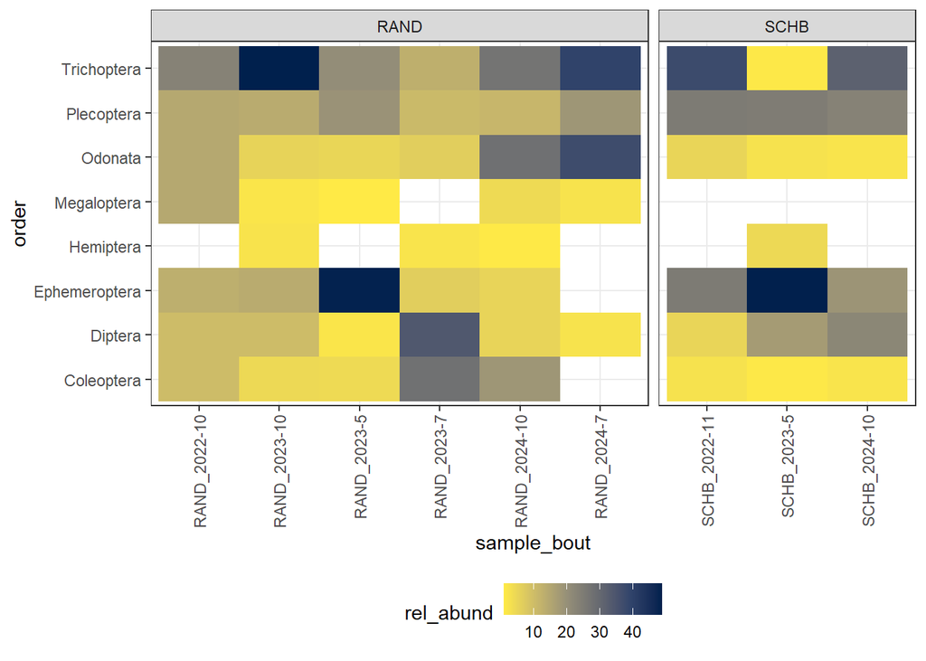

```r
ggplot(macros, aes(x = sample_bout, y = order, fill = rel_abund)) +
  geom_tile() +
  scale_fill_viridis_c(option = "E", direction = -1) +
  facet_grid(. ~ site_id, scales = "free", space = "free") +
  theme_bw() +
  theme(axis.text.x = element_text(angle = 90, vjust = 0.5, hjust=1),
        legend.position = "bottom")
```

Now you can make the same figure by family.